```python
import numpy as np
import pandas as pd

# df = pd.read_csv("case_study_1.csv")
# df = df.astype({"type":'category', "nameOrig":'category', 'nameDest': 'category','isFraud': 'category', 'isFlaggedFraud': 'category' })

df.head()
```

|  | step | type | amount | nameOrig | oldbalanceOrg | newbalanceOrig | nameDest | oldbalanceDest | newbalanceDest | isFraud | isFlaggedFraud | OrigType | DestType |
| --- | --- | --- | --- | --- | --- | --- | --- | --- | --- | --- | --- | --- | --- |
| 0 | 1 | PAYMENT | 9839.64 | C1231006815 | 170136.0 | 160296.36 | M1979787155 | 0.0 | 0.0 | 0 | 0 | C | M |
| 1 | 1 | PAYMENT | 1864.28 | C1666544295 | 21249.0 | 19384.72 | M2044282225 | 0.0 | 0.0 | 0 | 0 | C | M |
| 2 | 1 | TRANSFER | 181.00 | C1305486145 | 181.0 | 0.00 | C553264065 | 0.0 | 0.0 | 1 | 0 | C | C |
| 3 | 1 | CASH_OUT | 181.00 | C840083671 | 181.0 | 0.00 | C38997010 | 21182.0 | 0.0 | 1 | 0 | C | C |
| 4 | 1 | PAYMENT | 11668.14 | C2048537720 | 41554.0 | 29885.86 | M1230701703 | 0.0 | 0.0 | 0 | 0 | C | M |

```python
import seaborn as sns
from IPython.core.display import Image
import matplotlib.pyplot as plt
from sklearn.model_selection import train_test_split
```

# Data set summary

There are 6,362,620 transactions. We found on duplicates, no missing values.

Out of 6,362,620 records, there are only 8,213 (0.129%) transactions labeled as fraud. Since our goal is to develop fraudulent transaction prediction models, we have really inbalanced data set.

"The challenge of working with imbalanced datasets is that most machine learning techniques will ignore, and in turn have poor performance on, the minority class, although typically it is performance on the minority class that is most important." Especially in our case, our goal is to label the fraudulent transctions, the minority class.

"One approach to addressing imbalanced datasets is to oversample the minority class. The simplest approach involves duplicating examples in the minority class, although these examples don’t add any new information to the model. Instead, new examples can be synthesized from the existing examples. This is a type of data augmentation for the minority class and is referred to as the Synthetic Minority Oversampling Technique, or **SMOTE** for short."

There are 11 columns in the data set. Since we'd want to build the fraud prediction model, we'll ingore **isFlaggedFraud** column. **isFraud** column is our target label. We add two more columns by taking the first character from nameOrig and nameDest and we name them as DestType and OrigType, which indicate if the accounts are merchants or not. We'll explore the rest 11 columns to identify features which can be used in the prediction model.

- **nuemric variables** - amount, oldbalanceOrg, newbalanceOrig, oldbalanceDest, newbalanceDest
- **categorical variables** - type, nameOrig, nameDest, DestType, OrigType
- **step** - it indicates time sequence, we'd want to explore if converting them weekday and hour of the day better serve the model

## numeric variables

Firstly, we generate box plots without outliers with numeric variables. The blue boxes are for non-fraudulent transactions and the green boxes are for fraudulent transactions. Several interesting findings -

- fraudulent transactions tend to have **larger amounts**. (The mean of fraudulent transaction amount is larger than the mean of non-fraudulent transaction amount)

```python
Image(url= "figs/amount.png", width=500)
```

[figure not shown]

- fraudulent transactions tend to target on those accounts which have **larger original amounts**. (the mean of oldbalanceOrg of fraudulent transaction is larger.)
- after the fraudulent transaction, original account tends to have really small amount left.

```python
Image(url= "figs/org.png", width=1200)
```

[figure not shown]

We filtered the transactions to include transactions which have "Customer" accounts as destination for the following box plots.

- before the fraudulent transaction, destination account trends to have nearly zero amount in the account
- after the fraudulent transaction, destination account still has smaller amount of money

```python
Image(url= "figs/dest.png", width=1200)
```

[figure not shown]

## categorical variables

```python
Image(url= "figs/type.png", width=600)
```

[figure not shown]

The bars above represent the entire data set, the darker blue line represent Fraudulent transactions.

When we look into different type of transactions, CASH_IN and DEBIT contain no fraudulent transactions. Frauds happen on CASH_OUT and TRANSFER. Especially for TRANSFER type, about 1% TRANSFER transaction is fraudulent.

```python
temp = df[["nameDest", "isFraud", "DestType"]]
temp = temp.astype({"isFraud":'int64'})
tempgrouped = temp.groupby("DestType")['isFraud'].agg('sum').reset_index()
tempgrouped.sort_values(by='isFraud', ascending=False)
```

|  | DestType | isFraud |
| --- | --- | --- |
| 0 | C | 8213 |
| 1 | M | 0 |

```python
temp = df[["nameDest", "isFraud", "DestType"]]
temp = temp.astype({"isFraud":'int64'})
tempgrouped = temp.groupby("nameDest")['isFraud'].agg('sum').reset_index()
tempgrouped.groupby("isFraud").count()
```

| isFraud | nameDest |
| --- | --- |
| 0 | 2714193 |
| 1 | 8125 |
| 2 | 44 |

Majority of fraudulent accounts only make one fraudulent transactions. Only 44 (0.54%) accounts make two fraudulent transactions. There is no account which makes more than 2 fraudulent transactions.

## step

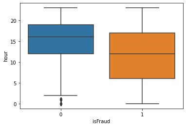

```python
df["hour"] = df.apply(lambda x : x["step"] % 24, axis = 1)
ax = sns.boxplot(x="isFraud", y="hour", data=df)
```

Firstly, we want to see if fraudulent transasctions happen in a specific time of a day. We convert step by (step % 24) (hour 0 does not mean 12:00am, it only indicates a unit of time.)

We found fraudulent transactions gather around hour 12, while non-fraudulent transactions gather around hour 16.

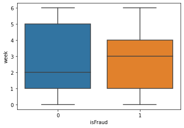

```python
df["day"] = df.apply(lambda x : x["step"] // 24, axis = 1)
df["week"] = df.apply(lambda x : x["day"] % 7, axis = 1)

ax = sns.boxplot(x="isFraud", y="week", data=df)
```

Secondly, we want to see if fraudulent transasctions happen in a specific day of a week. We convert step by (step // 24) to get the date and then convert date by (date % 7) to get the day of the week. (week 0 does not mean Monday, it only indicates a unit of time.)

# Feature Correlations

```python
df.columns
```

```
Index(['step', 'type', 'amount', 'nameOrig', 'oldbalanceOrg', 'newbalanceOrig',
       'nameDest', 'oldbalanceDest', 'newbalanceDest', 'isFraud',
       'isFlaggedFraud', 'OrigType', 'DestType', 'hour', 'day', 'week'],
      dtype='object')
```

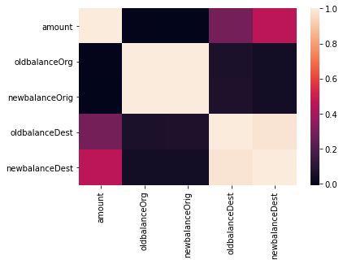

```python
corr = df[["amount", "oldbalanceOrg", "newbalanceOrig", "oldbalanceDest", "newbalanceDest"]].corr()

sns.heatmap(corr, xticklabels=corr.columns.values, yticklabels=corr.columns.values)
```

newbalanceOrig (newbalanceDest) and oldbalanceOrig (oldbalanceDest) are highly correleated. It's expected. Instead of using those two variables in our model, we can take the differences between the two, so that we won't have highly correlated variables in our model.

```python
df["diffOrig"] = df["newbalanceOrig"] - df["oldbalanceOrg"]
df["diffDest"] = df["newbalanceDest"] - df["oldbalanceDest"]
```

oldbalanceDest and newbalanceDest are also correlated with amount. Let's take a look of the scatter plots to have more insights on this relationship. The scatter plots show a weak positive relationship.

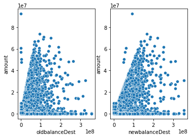

```python
fig, ax = plt.subplots(1,2)

sns.scatterplot(data=df, x='oldbalanceDest', y='amount', ax=ax[0])
sns.scatterplot(data=df, x='newbalanceDest', y='amount', ax=ax[1])

fig.show()
```

# feature engineering

we have already done some feature engineering and we'll further clean and encode features in the section. Firstly, we currently have the following columns

- type, OrigType, DestType (categorical)
- amount, diffOrig, diffDest (numeric)
- hour, week (numeric)

```python
y = df[["isFraud"]]

X = df[["type", "OrigType", "DestType", "amount","diffOrig", "diffDest", "hour", "week", 'oldbalanceOrg', 'newbalanceDest']]
X.head()
```

|  | type | OrigType | DestType | amount | diffOrig | diffDest | hour | week | oldbalanceOrg | newbalanceDest |
| --- | --- | --- | --- | --- | --- | --- | --- | --- | --- | --- |
| 0 | PAYMENT | C | M | 9839.64 | -9839.64 | 0.0 | 1 | 0 | 170136.0 | 0.0 |
| 1 | PAYMENT | C | M | 1864.28 | -1864.28 | 0.0 | 1 | 0 | 21249.0 | 0.0 |
| 2 | TRANSFER | C | C | 181.00 | -181.00 | 0.0 | 1 | 0 | 181.0 | 0.0 |
| 3 | CASH_OUT | C | C | 181.00 | -181.00 | -21182.0 | 1 | 0 | 181.0 | 0.0 |
| 4 | PAYMENT | C | M | 11668.14 | -11668.14 | 0.0 | 1 | 0 | 41554.0 | 0.0 |

We'll encode categorical variable.

```python
X = X.join(pd.get_dummies(X[['type']], prefix='type')).drop(['type'], axis=1)

X = X.join(pd.get_dummies(X[['DestType']], prefix='DestType')).drop(['DestType'], axis=1)
X = X.join(pd.get_dummies(X[['OrigType']], prefix='OrigType')).drop(['OrigType'], axis=1)
X.head()
```

|  | amount | diffOrig | diffDest | hour | week | oldbalanceOrg | newbalanceDest | type_CASH_IN | type_CASH_OUT | type_DEBIT | type_PAYMENT | type_TRANSFER | DestType_C | DestType_M | OrigType_C |
| --- | --- | --- | --- | --- | --- | --- | --- | --- | --- | --- | --- | --- | --- | --- | --- |
| 0 | 9839.64 | -9839.64 | 0.0 | 1 | 0 | 170136.0 | 0.0 | 0 | 0 | 0 | 1 | 0 | 0 | 1 | 1 |
| 1 | 1864.28 | -1864.28 | 0.0 | 1 | 0 | 21249.0 | 0.0 | 0 | 0 | 0 | 1 | 0 | 0 | 1 | 1 |
| 2 | 181.00 | -181.00 | 0.0 | 1 | 0 | 181.0 | 0.0 | 0 | 0 | 0 | 0 | 1 | 1 | 0 | 1 |
| 3 | 181.00 | -181.00 | -21182.0 | 1 | 0 | 181.0 | 0.0 | 0 | 1 | 0 | 0 | 0 | 1 | 0 | 1 |
| 4 | 11668.14 | -11668.14 | 0.0 | 1 | 0 | 41554.0 | 0.0 | 0 | 0 | 0 | 1 | 0 | 0 | 1 | 1 |

scale features

```python
# Scale Features
from sklearn.preprocessing import MinMaxScaler

min_max_scaler = MinMaxScaler()
x_scaled = min_max_scaler.fit_transform(X)
X = pd.DataFrame(x_scaled, columns=list(X.columns))
X.head()
```

|  | amount | diffOrig | diffDest | hour | week | oldbalanceOrg | newbalanceDest | type_CASH_IN | type_CASH_OUT | type_DEBIT | type_PAYMENT | type_TRANSFER | DestType_C | DestType_M | OrigType_C |
| --- | --- | --- | --- | --- | --- | --- | --- | --- | --- | --- | --- | --- | --- | --- | --- |
| 0 | 0.000106 | 0.838434 | 0.109987 | 0.043478 | 0.0 | 0.002855 | 0.0 | 0.0 | 0.0 | 0.0 | 1.0 | 0.0 | 0.0 | 1.0 | 0.0 |
| 1 | 0.000020 | 0.839103 | 0.109987 | 0.043478 | 0.0 | 0.000357 | 0.0 | 0.0 | 0.0 | 0.0 | 1.0 | 0.0 | 0.0 | 1.0 | 0.0 |
| 2 | 0.000002 | 0.839244 | 0.109987 | 0.043478 | 0.0 | 0.000003 | 0.0 | 0.0 | 0.0 | 0.0 | 0.0 | 1.0 | 1.0 | 0.0 | 0.0 |
| 3 | 0.000002 | 0.839244 | 0.109809 | 0.043478 | 0.0 | 0.000003 | 0.0 | 0.0 | 1.0 | 0.0 | 0.0 | 0.0 | 1.0 | 0.0 | 0.0 |
| 4 | 0.000126 | 0.838280 | 0.109987 | 0.043478 | 0.0 | 0.000697 | 0.0 | 0.0 | 0.0 | 0.0 | 1.0 | 0.0 | 0.0 | 1.0 | 0.0 |

# modeling

We split data into 30% for testing and 70% for training.

```python
from sklearn import metrics
from sklearn.tree import DecisionTreeClassifier
```

```python
X_train, X_test, y_train, y_test = train_test_split(X, y, test_size=0.3, random_state=1)
```

## decision tree

Firstly, we want to try decision tree.

**auc = 0.915**

```
<sklearn.metrics._plot.confusion_matrix.ConfusionMatrixDisplay at 0x7f9208e9c1f0>
```

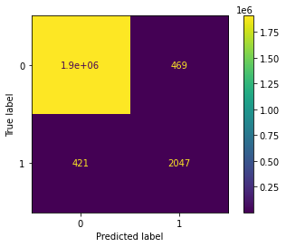

```python
clf = DecisionTreeClassifier()

clf = clf.fit(X_train,y_train)

y_pred = clf.predict(X_test)
metrics.plot_confusion_matrix(clf, X_test, y_test)
```

```python
fpr, tpr, thresholds = metrics.roc_curve(y_test, y_pred)
metrics.auc(fpr, tpr)
```

```
0.9145852537969268
```

```python
# case ii after scaling
print(metrics.classification_report(y_test, y_pred))
```

```
              precision    recall  f1-score   support

           0       1.00      1.00      1.00   1906318
           1       0.81      0.83      0.82      2468

    accuracy                           1.00   1908786
   macro avg       0.91      0.91      0.91   1908786
weighted avg       1.00      1.00      1.00   1908786
```

## random forecast

then we try random forecast.

**auc = 0.854**

```
0.8539268982272192
```

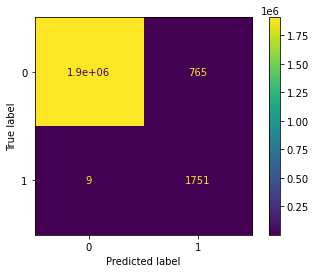

```python
# Fit random forest model
from sklearn import ensemble
from sklearn.metrics import classification_report,confusion_matrix
rfc = ensemble.RandomForestClassifier(max_depth=10,max_features='auto', n_estimators=40)
rfc.fit(X_train, y_train)
y_pred = rfc.predict(X_test)
metrics.plot_confusion_matrix(clf, X_test, y_pred)


fpr, tpr, thresholds = metrics.roc_curve(y_test, y_pred)
metrics.auc(fpr, tpr)
```

```python
# case ii after scaling
print(metrics.classification_report(y_test, y_pred))
```

```
              precision    recall  f1-score   support

           0       1.00      1.00      1.00   1906318
           1       0.99      0.71      0.83      2468

    accuracy                           1.00   1908786
   macro avg       1.00      0.85      0.91   1908786
weighted avg       1.00      1.00      1.00   1908786
```

## xgboost

```
[15:44:17] WARNING: /Users/travis/build/dmlc/xgboost/src/gbm/gbtree.cc:139: Tree method is automatically selected to be 'approx' for faster speed. To use old behavior (exact greedy algorithm on single machine), set tree_method to 'exact'.
```

```
<sklearn.metrics._plot.confusion_matrix.ConfusionMatrixDisplay at 0x7f92006a7bb0>
```

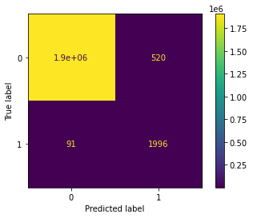

```python
# Fit xgboost
from xgboost import XGBClassifier
xgb = XGBClassifier()
xgb.fit(X_train, y_train)
y_pred = xgb.predict(X_test)

metrics.plot_confusion_matrix(clf, X_test, y_pred)
```

```python
fpr, tpr, thresholds = metrics.roc_curve(y_test, y_pred)
metrics.auc(fpr, tpr)
```

```
0.9075978326224382
```

```python
# case ii after scaling
print(metrics.classification_report(y_test, y_pred))
```

```
              precision    recall  f1-score   support

           0       1.00      1.00      1.00   1906318
           1       0.96      0.82      0.88      2468

    accuracy                           1.00   1908786
   macro avg       0.98      0.91      0.94   1908786
weighted avg       1.00      1.00      1.00   1908786
```

## SMOTE

We were planing to use SMOTE to sample the data but we were facing some python library installation issue with Jupyter notebook so I run python code via terminal and copied the results below. SMOTE will help us sample the data to solve the imbalance data set issue. We'll have better understanding of how good our model is.

```python
from imblearn.over_sampling import SMOTE
smt = SMOTE(random_state=0)
X_train_SMOTE, Y_train_SMOTE= smt.fit_resample(X_train, y_train)
X_test_SMOTE, Y_test_SMOTE= smt.fit_resample(X_test, y_test)
```

## xgboost

**auc = 0.995**

```
          precision    recall  f1-score   support

       0       0.99      1.00      0.99   1906318
       1       1.00      0.99      0.99   1906318

accuracy                           0.99   3812636
```

with data sampling, we have 1906318 transactions for both 0 and 1. We can see xgboost is a really robust model to produce good accurayc, recall and f1-score.

## further improvement

The improved method to predict fraudulent transaction is to use Graph Neural Networks - Link Prediction algorithm, which widely use in crypto currency transaction detection. The Link Prediction model generates each account ID as a Node and each transaction as a link, which finally make a network graph to display the relationship between each account. By exploring the relationship between each node and link, it can predict the abnormal transaction.

Since our data set has different features based on isFraud/isNotFraud, we can further use nodes as supervised information to improve the prediction accuracy by adding Graph Attention Network. By using Graph Attention Network, we can simply add several feature network layers into pre-trained model to find abnormal account and transaction.

### Note

some of the plots are generated by python EDA packages. We used several python EDA package, including Pandas UI, Pandas profiling, Sweetviz, Autoviz. The package helps us save some time at the beginning of the project.

### Reference

- SMOTE https://machinelearningmastery.com/smote-oversampling-for-imbalanced-classification/
- EDA package https://towardsdatascience.com/better-faster-stronger-python-exploratory-data-analysis-eda-e2a733890a64
- https://www.kaggle.com/stephenmso/fraud-detection
- Chen, Weili, et al. "Market manipulation of bitcoin: Evidence from mining the Mt. Gox transaction network." IEEE INFOCOM 2019-IEEE Conference on Computer Communications. IEEE, 2019.
- Gu, Weiwei, et al. "Link prediction via Graph attention network." arXiv preprint arXiv:1910.04807 (2019).